# IODS course project

Valentina KieseppÃ¤

## About the project

*Nice course*

https://github.com/valentinakieseppa/IODS-project

## Regression analysis

Reading the data into R and exploring it’s structure and dimensions:

```
## [1] 166   7
```

```
## 'data.frame':    166 obs. of  7 variables:
##  $ gender  : Factor w/ 2 levels "F","M": 1 2 1 2 2 1 2 1 2 1 ...
##  $ Age     : int  53 55 49 53 49 38 50 37 37 42 ...
##  $ attitude: num  3.7 3.1 2.5 3.5 3.7 3.8 3.5 2.9 3.8 2.1 ...
##  $ deep    : num  3.58 2.92 3.5 3.5 3.67 ...
##  $ stra    : num  3.38 2.75 3.62 3.12 3.62 ...
##  $ surf    : num  2.58 3.17 2.25 2.25 2.83 ...
##  $ Points  : int  25 12 24 10 22 21 21 31 24 26 ...
```

The data has 166 rows (observations) and 7 columns (variables). One of the variables, gender, is a factor with two levels.Others, including age, attitude, deep, stra, surf and points, are numeric.

Visualizing the data and inspecting summeries of the variables:

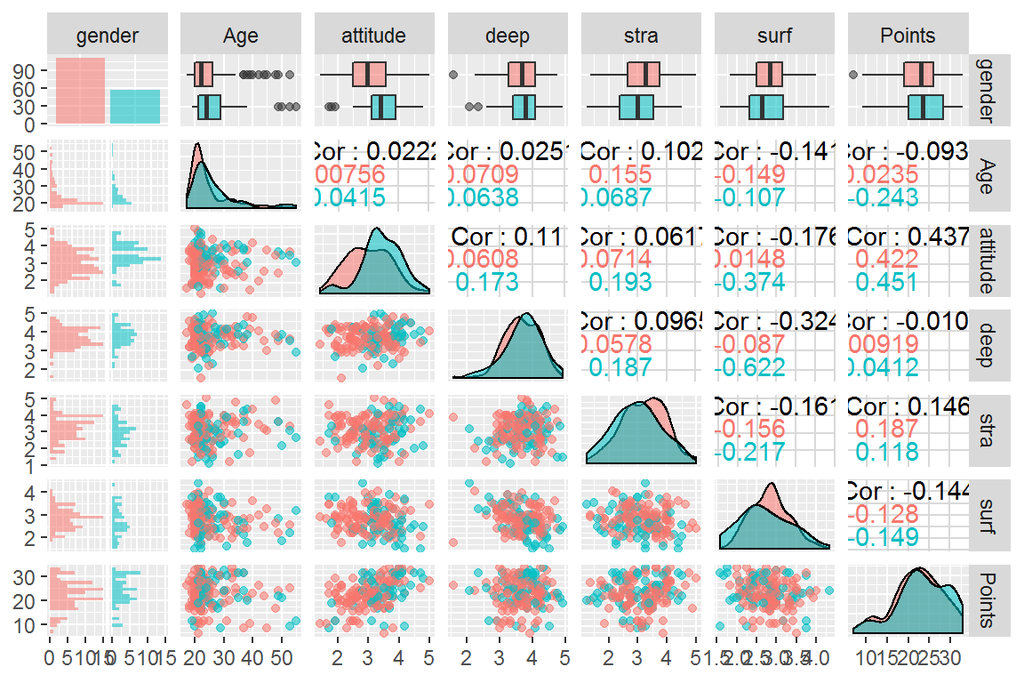

```
##  gender       Age           attitude          deep            stra
##  F:110   Min.   :17.00   Min.   :1.400   Min.   :1.583   Min.   :1.250
##  M: 56   1st Qu.:21.00   1st Qu.:2.600   1st Qu.:3.333   1st Qu.:2.625
##          Median :22.00   Median :3.200   Median :3.667   Median :3.188
##          Mean   :25.51   Mean   :3.143   Mean   :3.680   Mean   :3.121
##          3rd Qu.:27.00   3rd Qu.:3.700   3rd Qu.:4.083   3rd Qu.:3.625
##          Max.   :55.00   Max.   :5.000   Max.   :4.917   Max.   :5.000
##       surf           Points
##  Min.   :1.583   Min.   : 7.00
##  1st Qu.:2.417   1st Qu.:19.00
##  Median :2.833   Median :23.00
##  Mean   :2.787   Mean   :22.72
##  3rd Qu.:3.167   3rd Qu.:27.75
##  Max.   :4.333   Max.   :33.00
```

Fitting a regression line and showing the summary:

```
##
## Call:
## lm(formula = Points ~ attitude + stra + surf, data = learning2014)
##
## Residuals:
##      Min       1Q   Median       3Q      Max
## -17.1550  -3.4346   0.5156   3.6401  10.8952
##
## Coefficients:
##             Estimate Std. Error t value Pr(>|t|)
## (Intercept)  11.0171     3.6837   2.991  0.00322 **
## attitude      3.3952     0.5741   5.913 1.93e-08 ***
## stra          0.8531     0.5416   1.575  0.11716
## surf         -0.5861     0.8014  -0.731  0.46563
## ---
## Signif. codes:  0 '***' 0.001 '**' 0.01 '*' 0.05 '.' 0.1 ' ' 1
##
## Residual standard error: 5.296 on 162 degrees of freedom
## Multiple R-squared:  0.2074, Adjusted R-squared:  0.1927
## F-statistic: 14.13 on 3 and 162 DF,  p-value: 3.156e-08
```

Fitting the better model:

```
##
## Call:
## lm(formula = Points ~ attitude, data = learning2014)
##
## Residuals:
##      Min       1Q   Median       3Q      Max
## -16.9763  -3.2119   0.4339   4.1534  10.6645
##
## Coefficients:
##             Estimate Std. Error t value Pr(>|t|)
## (Intercept)  11.6372     1.8303   6.358 1.95e-09 ***
## attitude      3.5255     0.5674   6.214 4.12e-09 ***
## ---
## Signif. codes:  0 '***' 0.001 '**' 0.01 '*' 0.05 '.' 0.1 ' ' 1
##
## Residual standard error: 5.32 on 164 degrees of freedom
## Multiple R-squared:  0.1906, Adjusted R-squared:  0.1856
## F-statistic: 38.61 on 1 and 164 DF,  p-value: 4.119e-09
```

Attitude significantly explains Points (B=3.53, p < 0.001). Higher scores on attitude predict higher scores on Points. Multiple R-squared of 0.19 means that this model explains 19% of all the variaton in the dependent variable (points). This is generally considered a low R-squared value, although if you think about it, if “attitude” single-handedly explains 19 % of all the variation in “Points”, I would say it’s quite a lot!

Producing the diagnostic plots:

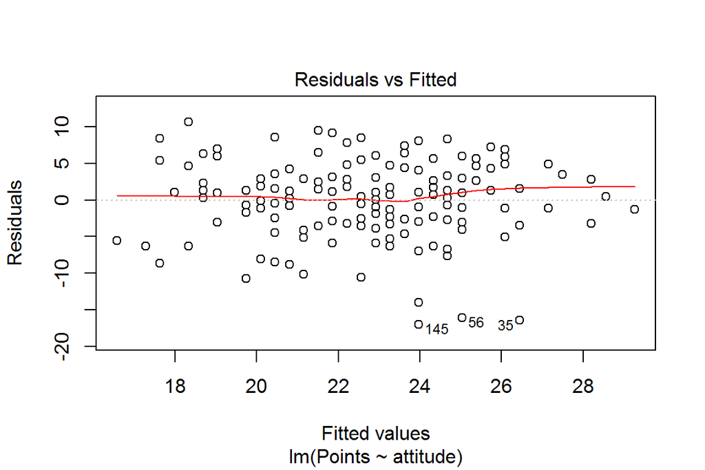

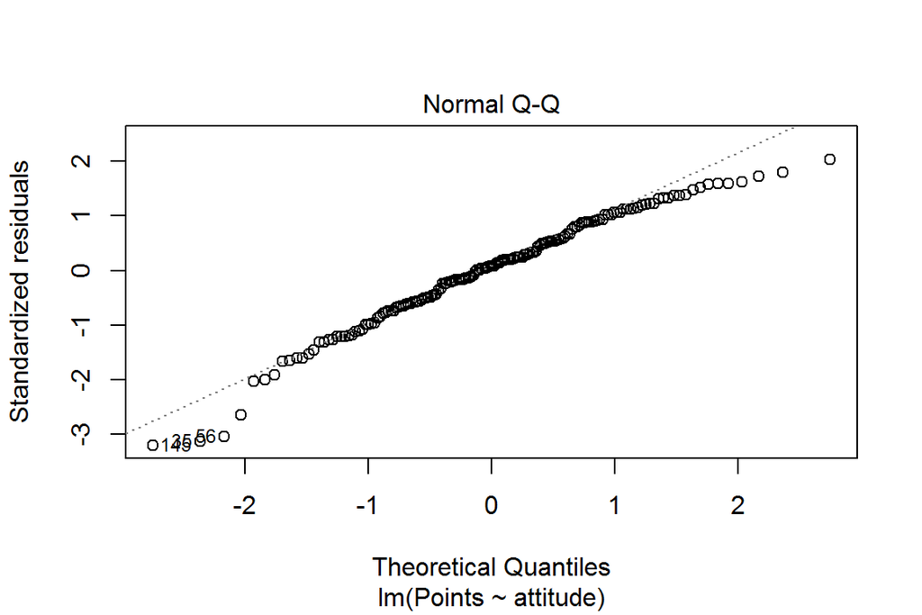

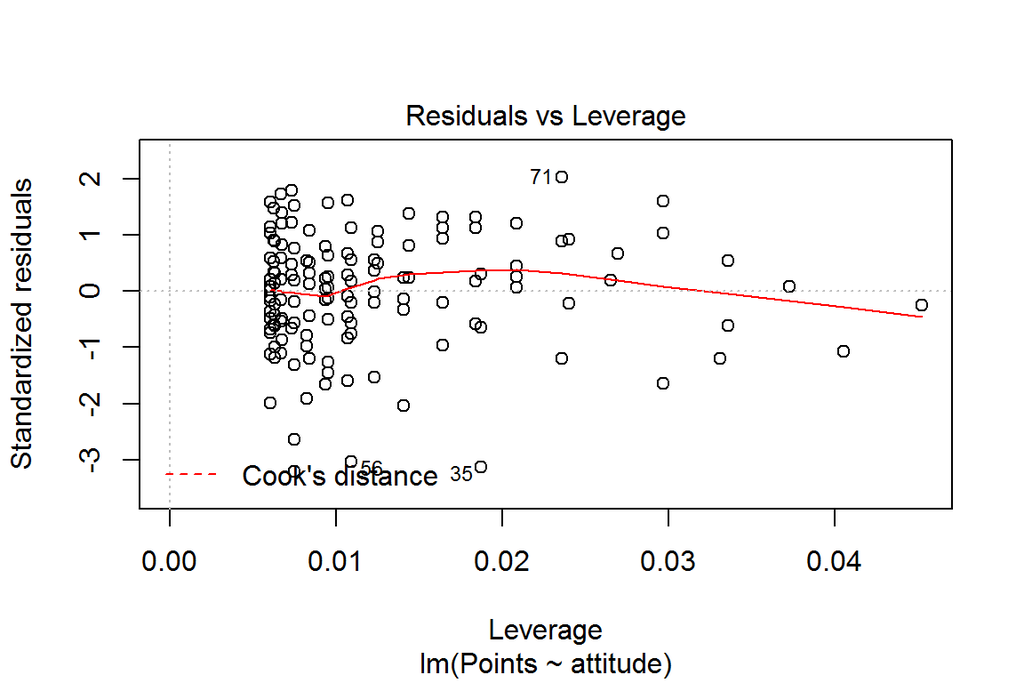

From the Residuals vs Fitted -plot we can see that size of the residuals does not depend on the explanatory variable, since there is no pattern to be seen in the scatterplot.QQ-plot is produced to evaluate wheter the residuals are normally distributed.It seems that the residuals fit reasonably well within the line, which means that they seem to fit to the normality assumption. From the Residuals vs Leverage plot we can see that no single value stands out with expectionally high leverage. In conclusion, our model seems to fit the standards!

## Logistic regression

Reading the data and printing out the variable names:

```
##  [1] "school"     "sex"        "age"        "address"    "famsize"
##  [6] "Pstatus"    "Medu"       "Fedu"       "Mjob"       "Fjob"
## [11] "reason"     "nursery"    "internet"   "guardian"   "traveltime"
## [16] "studytime"  "failures"   "schoolsup"  "famsup"     "paid"
## [21] "activities" "higher"     "romantic"   "famrel"     "freetime"
## [26] "goout"      "Dalc"       "Walc"       "health"     "absences"
## [31] "G1"         "G2"         "G3"         "alc_use"    "high_use"
```

Data combines two student alcohol consumption data sets. It includes 35 variables, which measure grades, alcohol use and different background charasteristics.

I choose variables “failures”, “absences”, “sex”, and “age” to predict higher alcohol use. I believe higher failures and higher absences wil be related to higher alcohol use. I believe that male sex and younger age will also predict higher alchol use.

Now, let’s explore the relationships of these variables and high alcohol use numerically and graphically.

Crosstabulation of the relationship between high_use and sex:

```
##
##                 F         M
##   FALSE 0.4083770 0.2931937
##   TRUE  0.1099476 0.1884817
```

Crosstabulation of the relationship between high_use and failures:

```
##
##                   0           1           2           3
##   FALSE 0.638743455 0.031413613 0.026178010 0.005235602
##   TRUE  0.235602094 0.031413613 0.023560209 0.007853403
```

Box plot of the relationship between high_use and absences (gender included):

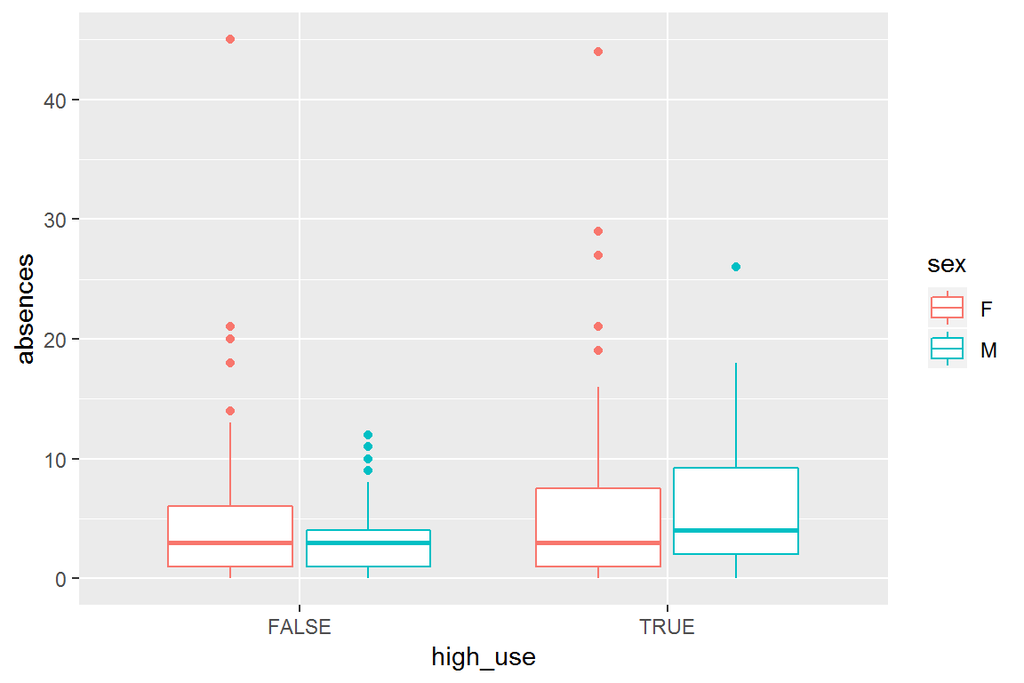

Box plot of the relationship between high_use and age (gender included):

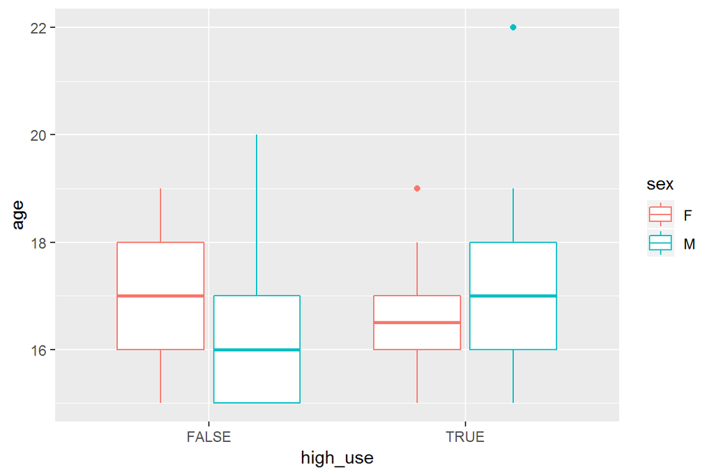

Okay, we can see that male sex, absences and failures are all related to higher alcohol consumption (as predicted). Older age seems to affect differently to men’s and women’s alchohol use and there doesn’t seem to be a straightfoward relationship between age and high use (unlike predicted).

Fitting the logistic regression model and producing its summary, odds ratios and confidence intervals for those odds ratios:

```
##
## Call:
## glm(formula = high_use ~ failures + absences + age + sex, family = "binomial",
##     data = alc)
##
## Deviance Residuals:
##     Min       1Q   Median       3Q      Max
## -2.2191  -0.8316  -0.6178   1.0504   2.1065
##
## Coefficients:
##             Estimate Std. Error z value Pr(>|z|)
## (Intercept) -4.15109    1.73220  -2.396   0.0166 *
## failures     0.40692    0.19443   2.093   0.0364 *
## absences     0.09039    0.02305   3.921 8.80e-05 ***
## age          0.13650    0.10384   1.315   0.1887
## sexM         0.94825    0.24256   3.909 9.26e-05 ***
## ---
## Signif. codes:  0 '***' 0.001 '**' 0.01 '*' 0.05 '.' 0.1 ' ' 1
##
## (Dispersion parameter for binomial family taken to be 1)
##
##     Null deviance: 465.68  on 381  degrees of freedom
## Residual deviance: 422.66  on 377  degrees of freedom
## AIC: 432.66
##
## Number of Fisher Scoring iterations: 4
```

```
##                     OR        2.5 %    97.5 %
## (Intercept) 0.01574723 0.0005033679 0.4540441
## failures    1.50218218 1.0261944393 2.2126966
## absences    1.09459580 1.0484251930 1.1477452
## age         1.14625201 0.9359125689 1.4073438
## sexM        2.58118308 1.6134349856 4.1835173
```

Let’s fit an adjusted model without the variable age.

```
##
## Call:
## glm(formula = high_use ~ failures + absences + sex, family = "binomial",
##     data = alc)
##
## Deviance Residuals:
##     Min       1Q   Median       3Q      Max
## -2.1855  -0.8371  -0.6000   1.1020   2.0209
##
## Coefficients:
##             Estimate Std. Error z value Pr(>|z|)
## (Intercept) -1.90297    0.22626  -8.411  < 2e-16 ***
## failures     0.45082    0.18992   2.374 0.017611 *
## absences     0.09322    0.02295   4.063 4.85e-05 ***
## sexM         0.94117    0.24200   3.889 0.000101 ***
## ---
## Signif. codes:  0 '***' 0.001 '**' 0.01 '*' 0.05 '.' 0.1 ' ' 1
##
## (Dispersion parameter for binomial family taken to be 1)
##
##     Null deviance: 465.68  on 381  degrees of freedom
## Residual deviance: 424.40  on 378  degrees of freedom
## AIC: 432.4
##
## Number of Fisher Scoring iterations: 4
```

```
##                    OR      2.5 %   97.5 %
## (Intercept) 0.1491257 0.09395441 0.228611
## failures    1.5695984 1.08339644 2.294737
## absences    1.0977032 1.05169654 1.150848
## sexM        2.5629682 1.60381392 4.149405
```

Now, let’s calcuate the predicted probabilites for “high_use”, add those predicted probabilites to the dataset, and use them to make a prediction. Here are cross tabulation of the correct predictions and a nice plot of them:

```
##         prediction
## high_use FALSE TRUE
##    FALSE   259    9
##    TRUE     84   30
```

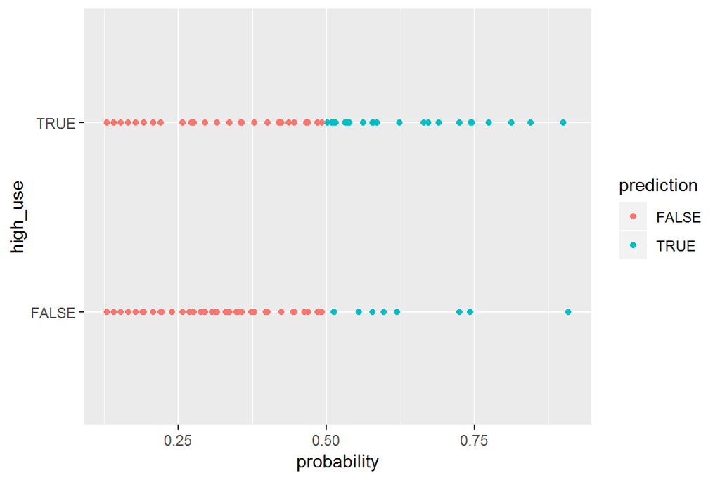

Defining a loss function to compute the average number of wrong predictions:

```
## [1] 0.2434555
```

From all of the 382 subjects, 268 were truly not high users of alcohol, an our model correclty identified 259 of them (97%) as non-high-users. Seems pretty good. However, 114 of these subjects were truly high users of alcohol, and our model identified only 30 one of them (26%). Not so great! We can calculate the average number of wrongly classified cases by hand from the 2x2-table ((9+84)/382 = 0.24), and we can see that that is the same number that the loss function produces. So 24% of the predictions went wrong, and most of those were false negatives. Let’s see if we could get better results by guessing. Let’s compute the averige number of wrong predictions with a probability of 0:

```
## [1] 0.2984293
```

We get 29% of average wrong classifications. With a probability of 0, everybody will be dumped in the “FALSE” category. Most of the predictions are still correct, because there are so much more of those non-high-users.

Let’s compute the averige number of wrong predictions with a probability of 1:

```
## [1] 0.7015707
```

70% of the classifications are wrong, because now everybody’s in the “TRUE”-category! Seems like our model indeed predicts the alcholol use better than by guessing (although not hugely so).

Then let’s do the cross-validation and calculate the average number of wrong predictions in cross-validation:

```
## [1] 0.2565445
```

The prediction error seems to stay between 0.24-0.26, so it seems to be pretty much the same as the model in datacamp.